# Resumen Radiomics

Iker González Tirado

28/6/2021

## Introducción

Las imágenes médicas han sido utilizadas y mejoradas durante muchos años, y aunque aparezcan nuevas técnicas para capturar estas imágenes, los métodos para interpretarlas siguen basandose en las mismas características que en los inicios.

Las imágenes radiologicas son conjuntos de datos donde cada píxel o vóxel es una medida física representada en una imagen. Estos valores pueden ser medidos mediante diferentes métodos.

Muchos análisis con escáners de última generación descartan mucha información irrelevante y muestran las partes más destacadas donde podría encontrarse una anomalía y así poder analizar si es causante de una enfermedad para decidir si intervenir o no hacerlo.

## Radiomics

Radiomics es el proceso de extraer cualidades de una zona destacada de una imagen radiológica mediante algoritmos para crear conjuntos de datos sobre las anormalidades que se encuentren en esta y que no se pueden observar a ojo.

Existen diferentes técnicas para realizar este trabajo: métricas basadas en intensidad, análisis basado en texturas, medidas basadas en la forma y métricas basadas en transformación. A continuación se explicará de manera más detallada en qué consiste cada una de estas técnicas:

Las métricas basadas en intensidad se calculan a partir de los propios valores de vóxel sin contar con ninguna información adicional que se pueda añadir en el análisis. Estas métricas se calculan marcando una zona destacada y extrayendo los valores de sus vóxeles. Estas estadísticas pueden ser agrupadas por promedio y variación, forma y diversidad.

El análisis basado en texturas se centra en la relación de espacio de los vóxeles. Intenta cuantificar parámetros como la intensidad, forma o color usando fórmulas matemáticas.

Las medidas basadas en la forma estudian la distribución de diferentes componentes y sus efectos en la placa. Hay diferentes tipos:

- 1D: miden la distancia entre dos puntos y se utilizan para describir la magnitud de una anormalidad y así saber la forma de la lesión.
- 2D: son planos que se utilizan para calcular parámetros basados en áreas.
- 3D: pretenden abarcar diferentes aspectos de forma tridimensional de manera similar al 2D.

Las métricas basadas en transformación utilizan el dominio de frecuencia, producto de la transformación de la imagen, para obtener la misma información, aunque ha de tenerse en cuenta que se centran en trabajar diferentes características ya que ofrecen diferentes posibilidades.

## Características

Las características destacadas o “features” tienen la capacidad de desvelar características de alguna enfermedad que no se pueden apreciar a simple vista, y por tanto se debe usar algún método para poder analizarlas; en este caso las radiomics.

## Tipos de características

Las características cuantitativas se pueden clasificar de la siguiente forma:

- Características de forma: Definen la región de interés y sus propiedades geométricas.
- Estadísticos de primera orden: Definen la distribución individual del valor de cada vóxel sin tener en cuenta la relación de espacio. Esto da a conocer la media, la mediana, el valor máximo y mínimo de la intensidad del vóxel, así como otros valores destacados.
- Estadísticos de segunda orden: Incluyen características de textura, que se obtienen calculando el valor de la relación entre vóxeles contiguos. Dan información sobre las intensidades entre los vóxeles siguiendo una dirección fija.
- Estadísticos de orden superior: Se obtienen a partir de métodos estadísticos después de aplicar filtros a las imágenes para identificar patrones.

## Ejemplo

En esta sección ilustramos cómo trabajar con los ficheros de imágenes para poder sacar los features. Este código no es reproducible porque se necesita un ordenador con más capacidad para poder ejecutar el código.

Cargamos las librerías de los paquetes RIA y RadAR.

```r
library(RIA)
library(RadAR)
library(RNifti)
```

Cargar cada imagen con su máscara.

```r
corona1 <- RIA::load_nifti(filename = "C:/Iker/ISGlobal/COVID-19/coronacases_001.nii.gz",
                           mask_filename = "C:/Iker/ISGlobal/COVID-19-MASK/coronacases_001.nii.gz")
corona2 <- RIA::load_nifti(filename = "C:/Iker/ISGlobal/COVID-19/coronacases_002.nii.gz",
                           mask_filename = "C:/Iker/ISGlobal/COVID-19-MASK/coronacases_002.nii.gz")
control1 <- RIA::load_nifti(filename = "C:/Iker/ISGlobal/COVID-19/radiopaedia_10_85902_1.nii.gz",
                            mask_filename = "C:/Iker/ISGlobal/COVID-19-MASK/radiopaedia_10_85902_1.nii.gz")
control2 <- RIA::load_nifti(filename = "C:/Iker/ISGlobal/COVID-19/radiopaedia_10_85902_3.nii.gz",
                            mask_filename = "C:/Iker/ISGlobal/COVID-19-MASK/radiopaedia_10_85902_3.nii.gz")
```

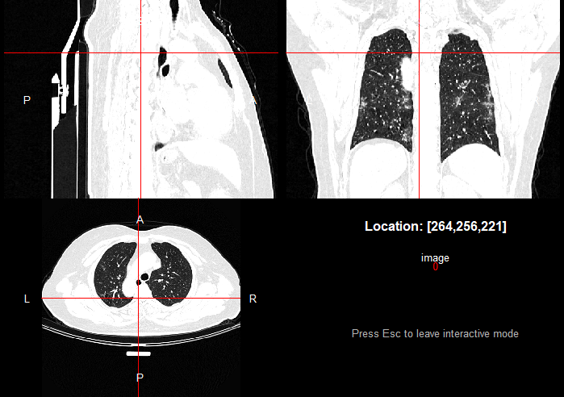

Imagen de un pulmón mediante CT Scan

```r
image <- readNifti("C:/Iker/ISGlobal/COVID-19/coronacases_001.nii.gz")
view(image)
```

Calcular las características de tipo first-order.

```r
stats_corona1 <- RIA::first_order(corona1)
stats_corona2 <- RIA::first_order(corona2)
stats_control1 <- RIA::first_order(control1)
stats_control2 <- RIA::first_order(control2)

stats_global <- data.frame(corona1 = stats_corona1,
                           corona2 = stats_corona2,
                           control1 = stats_control1,
                           control2 = stats_control2)
```

```r
stats_corona1 <- RIA:::list_to_df(corona1$stat_fo$orig)
stats_corona2 <- RIA:::list_to_df(corona2$stat_fo$orig)
stats_control1 <- RIA:::list_to_df(control1$stat_fo$orig)
stats_control2 <- RIA:::list_to_df(control2$stat_fo$orig)
```

```r
stats_global <- data.frame(corona1 = stats_corona1,
             corona2 = stats_corona2,
             control1 = stats_control1,
             control2 = stats_control2)
```

Cambiar el nombre de las columnas para cada individuo

```r
colnames(stats_global) <- c("corona1", "corona2", "control1", "control2")

head(stats_global)
```

Guardar archivo de la tabla

```r
write.table(stats_global, file = "C:/Iker/ISGlobal/Covid_features.txt", sep = "\t")
```

Importar las características

```r
rdr <- import_radiomic_table(file = "C:/Iker/ISGlobal/Covid_features.txt")
```

Crear una tabla con las características para cada individuo

```r
clinical <- data.frame(PatientID = c("corona1", "corona2", "control1", "control2"),
                       covid_status = c("covid", "covid", "no_covid", "no_covid"))

colData(rdr) <- cbind(colData(rdr), clinical)
```

Ver la correlación de las features

```r
plot_correlation_matrix(rdr = rdr,
                        method_correlation = "spearman",
                        view_as = "heatmap",
                        which_data = "normal")
```

Escalar los valores de las features

```r
rdr <- scale_feature_values(rdr = rdr, method = "minmax")
```

Agrupamiento de características

```r
rdr <- do_hierarchical_clustering(rdr = rdr,
                                  which_data = "scaled",
                                  method_dist_col = "correlation.spearman")

plot_heatmap_hcl(rdr = rdr,
                 annotation_tracks = c("covid_status"))
```

## Análisis de diez casos con Covid-19 y ocho controles

```r
rdr <- import_radiomic_table(file = "stats_global.tsv")
```

Crear una tabla con las características para cada individuo

```r
clinical <- data.frame(PatientID = c("corona1", "corona2", "corona3", "corona4", "corona5",
                                     "corona6", "corona7", "corona8", "corona9", "corona10",
                                     "control1", "control2", "control3", "control5",
                                     "control6", "control7", "control9", "control10"),
                       covid_status = c("covid", "covid", "covid", "covid", "covid",
                                        "covid", "covid", "covid", "covid", "covid",
                                        "no_covid", "no_covid", "no_covid",
                                        "no_covid", "no_covid", "no_covid", "no_covid", "no_covid"))

colData(rdr) <- cbind(colData(rdr), clinical)
```

Eliminar las filas sobrantes para poder ejecutar el código de manera correcta

```r
features.nodup <- assays(rdr)$values[-which(apply(assays(rdr)$values, 1, function(x){length(unique(x)) == 1})),]

rdr_2 <- SummarizedExperiment::SummarizedExperiment(assays = list(values = features.nodup),
                                                    rowData = data.frame(feature_name = rownames(features.nodup)), colData = colnames(features.nodup),metadata = metadata(rdr))

colData(rdr_2) <- cbind(colData(rdr_2), clinical)
```

Ver la correlación de las features

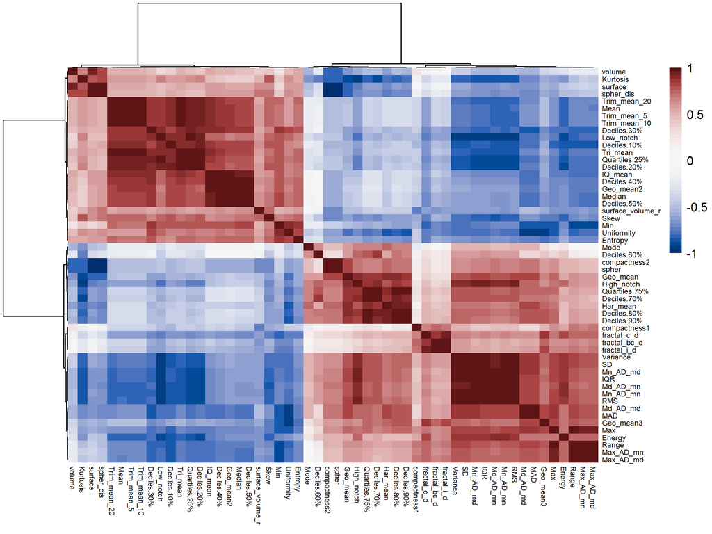

```r
plot_correlation_matrix(rdr = rdr_2,
                        method_correlation = "spearman",
                        view_as = "heatmap",
                        which_data = "normal")
```

Escalar los valores de las features

```r
rdr_2 <- scale_feature_values(rdr = rdr_2, method = "minmax")
```

Agrupamiento de características

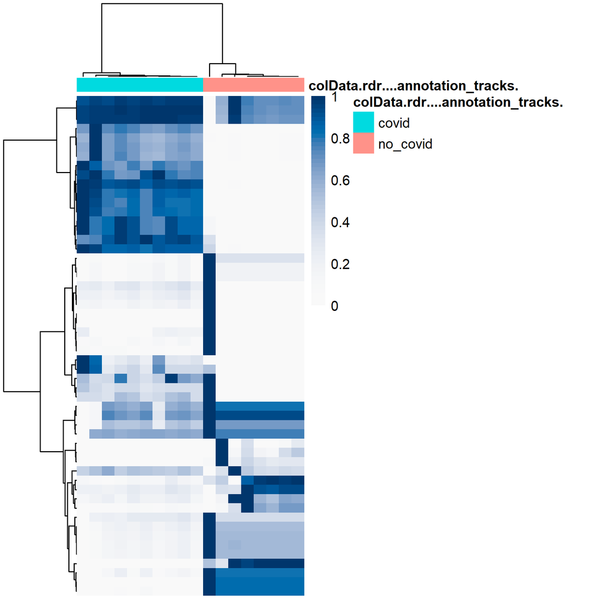

```r
rdr_2 <- do_hierarchical_clustering(rdr = rdr_2,
                                    which_data = "scaled",
                                    method_dist_col = "correlation.spearman")

plot_heatmap_hcl(rdr = rdr_2,
                 annotation_tracks = c("covid_status"))
```